# SHQ量表信效度分析

#导入文本文件

```r
DSJ40<-read.delim("DSJ40.txt",header=F)
dim(DSJ40)
```

```
## [1] 107  35
```

```r
head(DSJ40)
```

```
##    V1 V2 V3   V4 V5 V6 V7 V8 V9 V10 V11 V12 V13 V14 V15 V16      V17 V18
## 1  51 女 18 耳蜗  6  4  5  5  4   4   4   4   8   5   9   9 5.583333  70
## 2  53 男 49 耳蜗  9  7  7  6  4   7   3   5   5   8   8   8 6.416667  90
## 3  54 女 57 耳蜗  9  9  8  7  7   8   8   7   7   7  10  10 8.083333  70
## 4 107 男 15 耳蜗  2  2  0  1  1   6   0   0   3   2   2   5 2.000000  40
## 5  60 女 21 耳蜗  5  2  6  3  5   7   4   3   2   5   6   3 4.250000  60
## 6 109 女 21 耳蜗  6  7  2  5  6   7   5   5   7   3   7   4 5.333333  70
##   V19 V20 V21 V22 V23 V24 V25 V26 V27 V28 V29      V30      V31 V32   V33
## 1  70  70  70  70  50  50  50  50  50  50  50 58.33333 35.78208
## 2  90  90  90  90  90  90  70  70  80  80  90 85.00000  43.9155
## 3  70  70  70  70  70  70  70  70  70  70  70 70.00000    37.57
## 4  20  40  35  20  55  60  40  50  70  70  30 44.16667  37.2851 30%    25
## 5  65  45  50  55  35  55  63  45  55  60  30 51.50000     35.5 80%    25
## 6  60  45  55  40  30  50  40  40  55  65  55 50.41667     32.4 80% 36.25
##     V34     V35
## 1    NA 术后1年
## 2    NA 术后1年
## 3    NA 术后1年
## 4 115.0 术后3月
## 5  22.5 术后3月
## 6  20.0 术后3月
```

```r
DataSHQ = DSJ40[,18:29]
head(DataSHQ)
```

```
##   V18 V19 V20 V21 V22 V23 V24 V25 V26 V27 V28 V29
## 1  70  70  70  70  70  50  50  50  50  50  50  50
## 2  90  90  90  90  90  90  90  70  70  80  80  90
## 3  70  70  70  70  70  70  70  70  70  70  70  70
## 4  40  20  40  35  20  55  60  40  50  70  70  30
## 5  60  65  45  50  55  35  55  63  45  55  60  30
## 6  70  60  45  55  40  30  50  40  40  55  65  55
```

```r
#library(Scale)
names(DataSHQ)<-c("Q1","Q2","Q3","Q4","Q5","Q6","Q7","Q8","Q9","Q10","Q11","Q12")
```

```r
DataSHQ<-as.vector(DataSHQ)
```

#KMO检验

```r
library(MASS)
  X<- cor(as.matrix(DataSHQ))
  iX<- ginv(X)
  S2<- diag(diag((iX^-1)))
  AIS<- S2%*%iX%*%S2              # anti-image covariance matrix
  Dai<- sqrt(diag(diag(AIS)))
  AIR <- ginv(Dai)%*%AIS%*%ginv(Dai)        # anti-image correlation matrix
  a <- apply((AIR - diag(diag(AIR)))^2, 2, sum)
  AA <- sum(a)
  b <- apply((X - diag(nrow(X)))^2, 2, sum)
  BB <- sum(b)
  kmo <- BB/(AA+BB)         # overall KMO statistic
  kmo
```

```
## [1] 0.9058716
```

#因子分析，方差最大，因子载荷矩阵

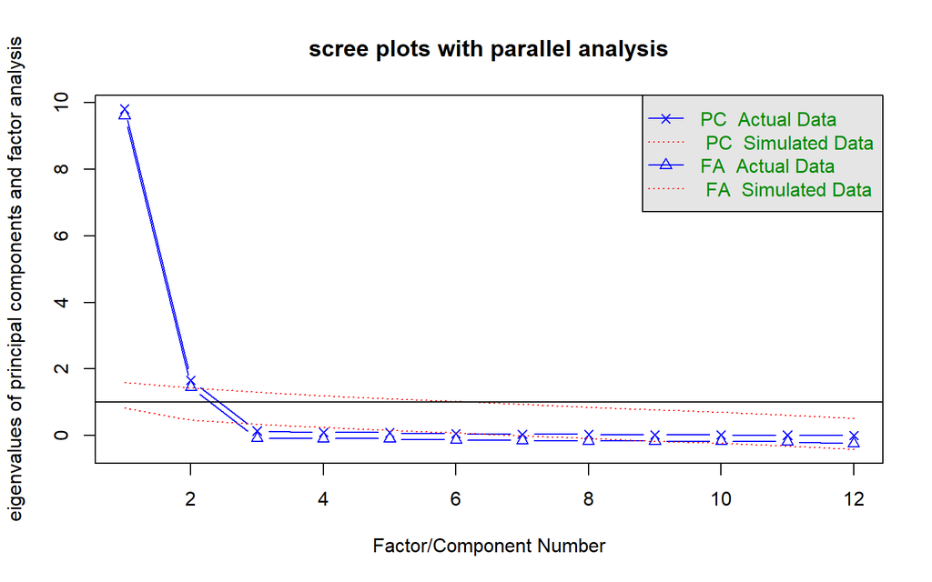

```
## Parallel analysis suggests that the number of factors =  2  and the number of components =  2
```

```r
library(psych)
covariances<-cov(DataSHQ)
correlations<-cov2cor(covariances)
fa<-fa.parallel(correlations,n.obs=107,fa="both",n.iter=100,main="scree plots with parallel analysis")
```

#由碎石图判断出，应取两个公因子，并用最大方差旋转得到载荷矩阵，两个公因子方差累计贡献率为94.8%

```r
fa.varimax<-fa(correlations,nfactors=2,rotate="varimax",fm="pa")
fa.varimax$loadings
```

```
##
## Loadings:
##     PA1   PA2
## Q1  0.908 0.367
## Q2  0.911 0.357
## Q3  0.917 0.343
## Q4  0.921 0.364
## Q5  0.906 0.363
## Q6  0.872 0.402
## Q7  0.389 0.891
## Q8  0.409 0.889
## Q9  0.416 0.882
## Q10 0.346 0.905
## Q11 0.332 0.907
## Q12 0.468 0.834
##
##                  PA1   PA2
## SS loadings    5.867 5.506
## Proportion Var 0.489 0.459
## Cumulative Var 0.489 0.948
```

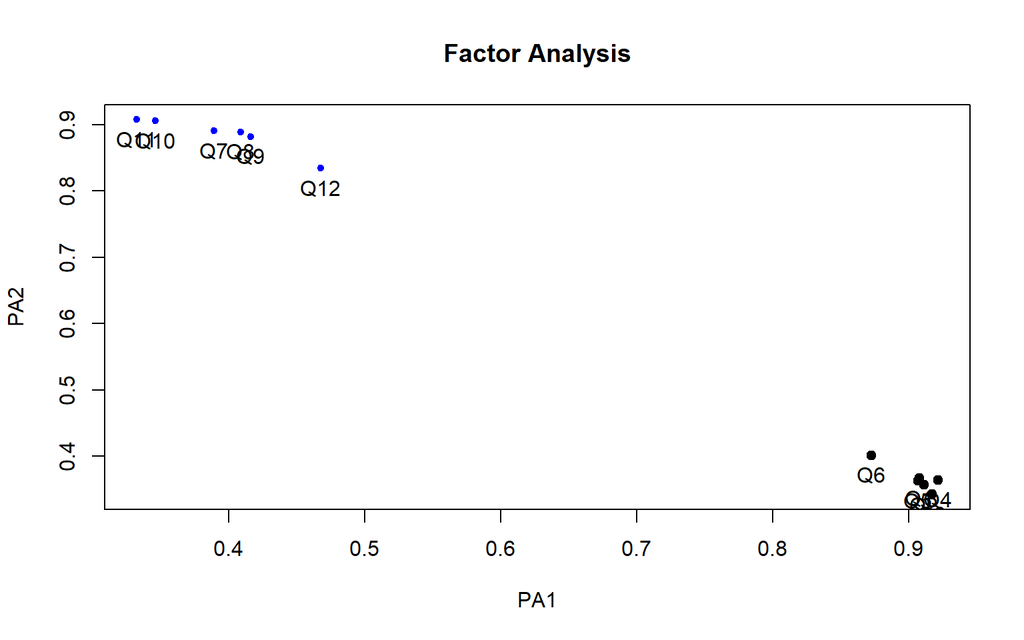

```r
factor.plot(fa.varimax,labels=rownames(fa.varimax$loadings))
```

##回归法计算因子得分

```r
fa<-factanal(~.,factors=2,data=DataSHQ,scores="regression")
scs<-fa$scores
head(scs)
```

```
##       Factor1      Factor2
## 1  0.36318457 -0.958906565
## 2  0.88810569 -0.065264311
## 3  0.04411426  0.004348902
## 4 -1.39382836 -0.132571772
## 5 -0.50078298 -0.443493854
## 6 -0.35058373 -0.771345748
```

#正常人与非正常得分比较 t检验,通过显著性检验，SHQ总分可以体现正常人与非正常人的差异；第一因子与第二因子也都通过检验 #SHQ总分比较

```r
SDataSHQ<-apply(DataSHQ,1,sum)
norm<-SDataSHQ[58:107]
dnorm<-SDataSHQ[-(58:107)]
outcome<-data.frame(
x=c(norm,dnorm),
a=factor(rep(1:2,c(50,57)))
)
t.test(x~a,alternative = "two.sided", var.equal = FALSE,data=outcome)
```

```
##
##  Welch Two Sample t-test
##
## data:  x by a
## t = 11.276, df = 72.563, p-value < 2.2e-16
## alternative hypothesis: true difference in means is not equal to 0
## 95 percent confidence interval:
##  344.7641 492.8253
## sample estimates:
## mean in group 1 mean in group 2
##       1052.9000        634.1053
```

#第一因子比较

```r
F1DataSHQ<-scs[,1]
norm1<-F1DataSHQ[58:107]
dnorm1<-F1DataSHQ[-(58:107)]
outcome1<-data.frame(
x1=c(norm1,dnorm1),
a1=factor(rep(1:2,c(50,57))))
t.test(x1~a1,alternative = "two.sided", var.equal = FALSE,data=outcome1)
```

```
##
##  Welch Two Sample t-test
##
## data:  x1 by a1
## t = 6.2447, df = 78.187, p-value = 2.055e-08
## alternative hypothesis: true difference in means is not equal to 0
## 95 percent confidence interval:
##  0.679448 1.315396
## sample estimates:
## mean in group 1 mean in group 2
##       0.5313368      -0.4660850
```

#第二因子比较

```r
F2DataSHQ<-scs[,2]
norm2<-F2DataSHQ[58:107]
dnorm2<-F2DataSHQ[-(58:107)]
outcome2<-data.frame(
x2=c(norm2,dnorm2),
a2=factor(rep(1:2,c(50,57)))
)
t.test(x2~a2,alternative = "two.sided", var.equal = FALSE,data=outcome2)
```

```
##
##  Welch Two Sample t-test
##
## data:  x2 by a2
## t = 6.6583, df = 70.32, p-value = 5.122e-09
## alternative hypothesis: true difference in means is not equal to 0
## 95 percent confidence interval:
##  0.7270783 1.3488612
## sample estimates:
## mean in group 1 mean in group 2
##       0.5529372      -0.4850326
```

#耳聋患者共57名，,第8位和第37位存在数据缺失和错误 #SHQ得分与声源定位的相关性(耳聋55例)

```r
Data<-DSJ40[1:57,c(18:29,31)]
dataSHQ<-Data[c(-8,-37),]
SHQ<-apply(dataSHQ[,-13],1,sum)
RMS<-dataSHQ[,13]
F1<-scs[c(1:7,9:36,38:57),1]
F2<-scs[c(1:7,9:36,38:57),2]
newdata<-data.frame(F1,F2,RMS,SHQ)
##将S表格导出到excel
#setwd("D:\rstudio")
#write.table(newdata,"newdata.csv",sep=",")
newdata1<-read.csv("newdata.csv",header=T)
covariances<-cov(newdata1)
correlations<-cov2cor(covariances)
correlations
```

```
##              F1         F2         RMS        SHQ
## F1   1.00000000 -0.3558318  0.06045855  0.5743859
## F2  -0.35583183  1.0000000 -0.71062675  0.5590118
## RMS  0.06045855 -0.7106268  1.00000000 -0.5602125
## SHQ  0.57438594  0.5590118 -0.56021246  1.0000000
```

```r
cor.test(newdata1$RMS,newdata1$SHQ,alternative="two.side",method="pearson")
```

```
##
##  Pearson's product-moment correlation
##
## data:  newdata1$RMS and newdata1$SHQ
## t = -4.9235, df = 53, p-value = 8.687e-06
## alternative hypothesis: true correlation is not equal to 0
## 95 percent confidence interval:
##  -0.7186952 -0.3463979
## sample estimates:
##        cor
## -0.5602125
```

#人工耳蜗植入前后的SHQ得分比较 #SHQ总分比较

```r
before<-SDataSHQ[19:57]
after<-SDataSHQ[1:18]
compare<-data.frame(
x3=c(before,after),
a3=factor(rep(1:2,c(39,18)))
)
t.test(x3~a3,alternative = "two.sided", var.equal = FALSE,data=compare)
```

```
##
##  Welch Two Sample t-test
##
## data:  x3 by a3
## t = 2.6856, df = 25.578, p-value = 0.01254
## alternative hypothesis: true difference in means is not equal to 0
## 95 percent confidence interval:
##   49.12951 370.80211
## sample estimates:
## mean in group 1 mean in group 2
##        700.4103        490.4444
```